# ANOVA - Online Retail

```python
import pandas as pd
import numpy as np
import matplotlib.pyplot as plt
import seaborn as sns
import scipy.stats as stats
import statsmodels.api as sm
from statsmodels.formula.api import ols
import statsmodels.formula.api as smf
import scikit_posthocs as sp


sns.set_palette("Set2")
```

```python
df1 = pd.read_csv('Year 2009-2010.csv', encoding='unicode_escape')
df2 = pd.read_csv('Year 2010-2011.csv', encoding='unicode_escape')
df = pd.concat([df1, df2])
df.tail()
```

|  | Invoice | StockCode | Description | Quantity | InvoiceDate | Price | Customer ID | Country |
| --- | --- | --- | --- | --- | --- | --- | --- | --- |
| 541905 | 581587 | 22899 | CHILDREN'S APRON DOLLY GIRL | 6 | 12/9/2011 12:50 | 2.10 | 12680.0 | France |
| 541906 | 581587 | 23254 | CHILDRENS CUTLERY DOLLY GIRL | 4 | 12/9/2011 12:50 | 4.15 | 12680.0 | France |
| 541907 | 581587 | 23255 | CHILDRENS CUTLERY CIRCUS PARADE | 4 | 12/9/2011 12:50 | 4.15 | 12680.0 | France |
| 541908 | 581587 | 22138 | BAKING SET 9 PIECE RETROSPOT | 3 | 12/9/2011 12:50 | 4.95 | 12680.0 | France |
| 541909 | 581587 | POST | POSTAGE | 1 | 12/9/2011 12:50 | 18.00 | 12680.0 | France |

```python
print(df.info())
```

```
<class 'pandas.core.frame.DataFrame'>
Index: 1067371 entries, 0 to 541909
Data columns (total 8 columns):
 #   Column       Non-Null Count    Dtype
---  ------       --------------    -----
 0   Invoice      1067371 non-null  object
 1   StockCode    1067371 non-null  object
 2   Description  1062989 non-null  object
 3   Quantity     1067371 non-null  int64
 4   InvoiceDate  1067371 non-null  object
 5   Price        1067371 non-null  float64
 6   Customer ID  824364 non-null   float64
 7   Country      1067371 non-null  object
dtypes: float64(2), int64(1), object(5)
memory usage: 73.3+ MB
None
```

```python
df.describe()
```

|  | Quantity | Price | Customer ID |
| --- | --- | --- | --- |
| count | 1.067371e+06 | 1.067371e+06 | 824364.000000 |
| mean | 9.938898e+00 | 4.649388e+00 | 15324.638504 |
| std | 1.727058e+02 | 1.235531e+02 | 1697.464450 |
| min | -8.099500e+04 | -5.359436e+04 | 12346.000000 |
| 25% | 1.000000e+00 | 1.250000e+00 | 13975.000000 |
| 50% | 3.000000e+00 | 2.100000e+00 | 15255.000000 |
| 75% | 1.000000e+01 | 4.150000e+00 | 16797.000000 |
| max | 8.099500e+04 | 3.897000e+04 | 18287.000000 |

```python
df.isna().sum()
```

```
Invoice             0
StockCode           0
Description      4382
Quantity            0
InvoiceDate         0
Price               0
Customer ID    243007
Country             0
dtype: int64
```

## Análise de dados

### Distribuição dos países

```python
df['Country'].value_counts()
```

```
Country
United Kingdom          981330
EIRE                     17866
Germany                  17624
France                   14330
Netherlands               5140
Spain                     3811
Switzerland               3189
Belgium                   3123
Portugal                  2620
Australia                 1913
Channel Islands           1664
Italy                     1534
Norway                    1455
Sweden                    1364
Cyprus                    1176
Finland                   1049
Austria                    938
Denmark                    817
Unspecified                756
Greece                     663
Japan                      582
Poland                     535
USA                        535
United Arab Emirates       500
Israel                     371
Hong Kong                  364
Singapore                  346
Malta                      299
Iceland                    253
Canada                     228
Lithuania                  189
RSA                        169
Bahrain                    126
Brazil                      94
Thailand                    76
Korea                       63
European Community          61
Lebanon                     58
West Indies                 54
Bermuda                     34
Nigeria                     32
Czech Republic              30
Saudi Arabia                10
Name: count, dtype: int64
```

```python
df = df[df['Country'] != 'Unspecified'].reset_index(drop=True)
```

### Distribuição dos preços

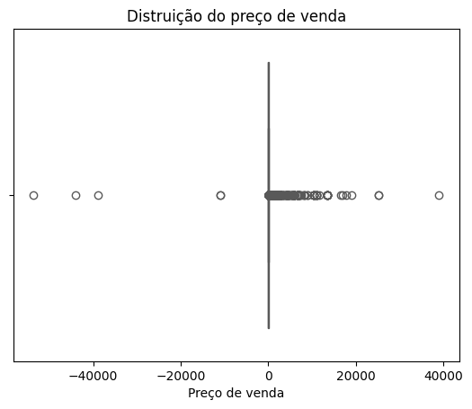

```python
sns.boxplot(x=df["Price"])
plt.xlabel("Preço de venda")
plt.title("Distruição do preço de venda")
plt.show()
```

```python
df[df['Price'] < 0]
```

|  | Invoice | StockCode | Description | Quantity | InvoiceDate | Price | Customer ID | Country |
| --- | --- | --- | --- | --- | --- | --- | --- | --- |
| 179324 | A506401 | B | Adjust bad debt | 1 | 4/29/2010 13:36 | -53594.36 | NaN | United Kingdom |
| 276126 | A516228 | B | Adjust bad debt | 1 | 7/19/2010 11:24 | -44031.79 | NaN | United Kingdom |
| 403213 | A528059 | B | Adjust bad debt | 1 | 10/20/2010 12:04 | -38925.87 | NaN | United Kingdom |
| 824830 | A563186 | B | Adjust bad debt | 1 | 8/12/2011 14:51 | -11062.06 | NaN | United Kingdom |
| 824831 | A563187 | B | Adjust bad debt | 1 | 8/12/2011 14:52 | -11062.06 | NaN | United Kingdom |

```python
df = df[df['Price'] > 0].reset_index(drop=True)
```

```python
df[df['Price'] == 0]
```

|  | Invoice | StockCode | Description | Quantity | InvoiceDate | Price | Customer ID | Country |
| --- | --- | --- | --- | --- | --- | --- | --- | --- |

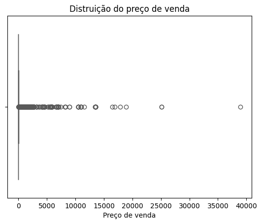

```python
sns.boxplot(x=df["Price"])
plt.xlabel("Preço de venda")
plt.title("Distruição do preço de venda")
plt.show()
```

### Distribuição de quantidades

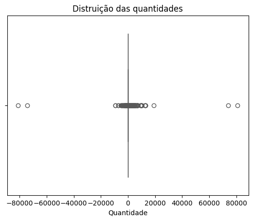

```python
sns.boxplot(x=df["Quantity"])
plt.xlabel("Quantidade")
plt.title("Distruição das quantidades")
plt.show()
```

```python
df = df[df['Quantity'] > 0].reset_index(drop=True)
```

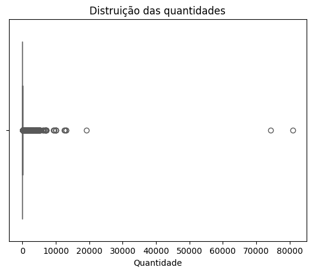

```python
sns.boxplot(x=df["Quantity"])
plt.xlabel("Quantidade")
plt.title("Distruição das quantidades")
plt.show()
```

### Quantidade de produtos por país

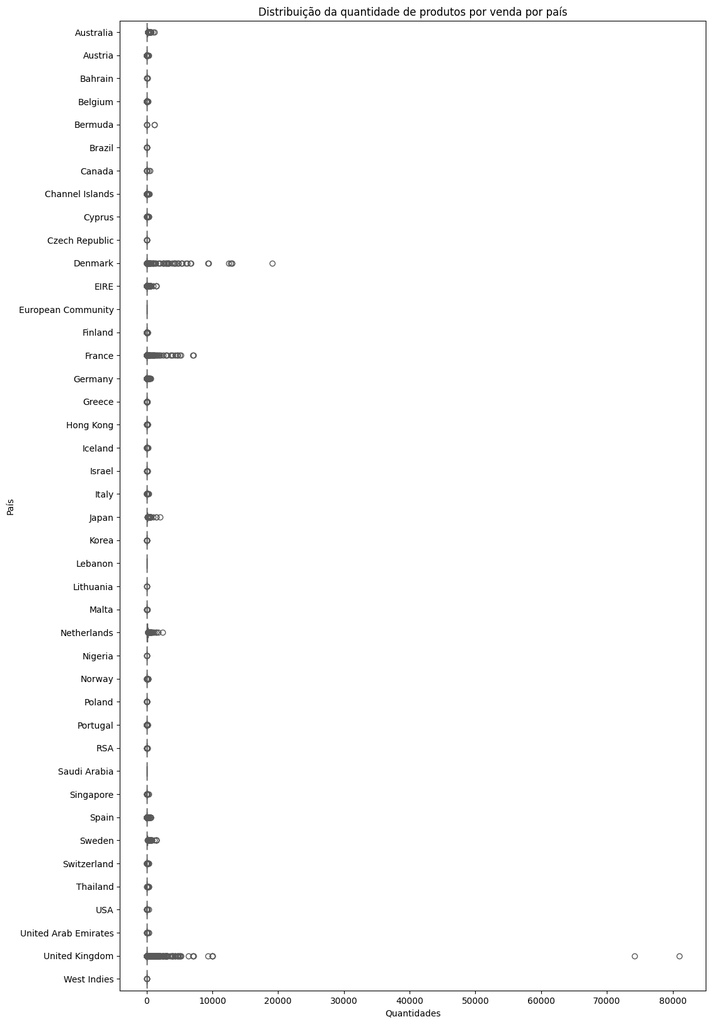

```python
plt.figure(figsize=(12, 20))

sns.boxplot(
    data=df.sort_values(by='Country'),
    x='Quantity',
    y='Country',
    palette='Set2',
    hue='Country',
)

plt.title('Distribuição da quantidade de produtos por venda por país')
plt.ylabel('País')
plt.xlabel('Quantidades')


plt.show()
```

### Preços das vendas por país

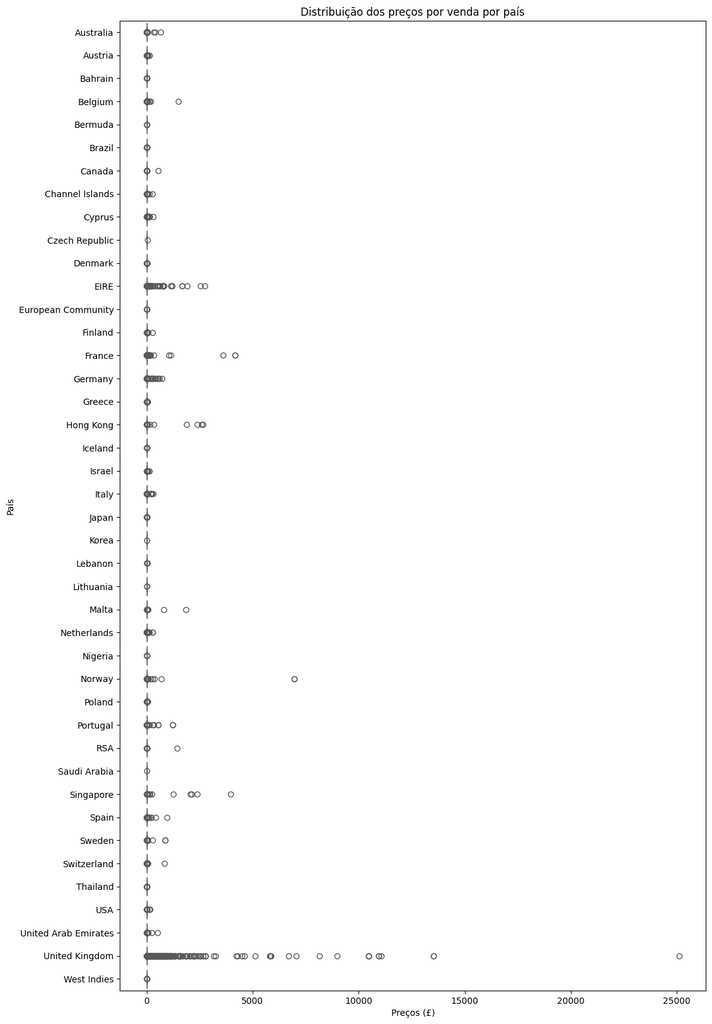

```python
plt.figure(figsize=(12, 20))

sns.boxplot(
    data=df.sort_values(by='Country'),
    x='Price',
    y='Country',
    palette='Set2',
    hue='Country',
)

plt.title('Distribuição dos preços por venda por país')
plt.ylabel('País')
plt.xlabel('Preços (£)')


plt.show()
```

## Verificação de pressupostos

```python
countries = df['Country'].unique()

quantity_groups = [df[df["Country"] == country]["Quantity"] for country in countries]
price_groups = [df[df["Country"] == country]["Price"] for country in countries]
```

### Normalidade

Para verificar que os dados de cada grupo seguem uma distribuição normal, dois testes serão usados:

Gŕafico Q-Q: ferramenta visual usada para comparar a distribuição dos dados com a distribuição normal. Se os pontos no gráfico Q-Q seguirem uma linha reta (diagonal), isso sugere que os dados seguem uma distribuição normal.

Teste de Shapiro-Wilk: teste estatístico utilizado para avaliar a normalidade dos dados. A hipótese nula do teste é que os dados seguem uma distribuição normal. Se o p-valor do teste for superior a um determinado nível de significância (geralmente 0.05), não se pode rejeitar a hipótese nula, ou seja, os dados podem ser considerados normalmente distribuídos.

#### Gráfico Q-Q - Preços

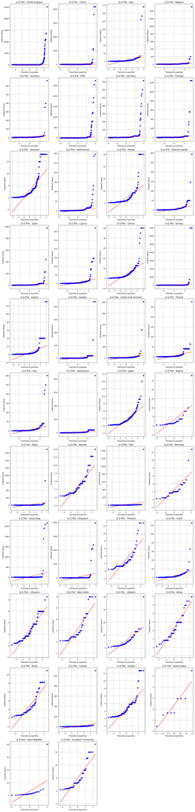

```python
ncols = 4
nrows = (len(countries) + ncols - 1) // ncols

fig, axes = plt.subplots(nrows=nrows, ncols=ncols, figsize=(16, 6 * nrows))

axes = np.array(axes).flatten() if isinstance(axes, np.ndarray) else [axes]

for i, c in enumerate(countries):
    group = df[df['Country'] == c]['Price']

    ax = axes[i]
    stats.probplot(group, dist="norm", plot=ax)

    ax.set_title(f"Q-Q Plot - {c}")
    ax.grid(True)

for j in range(i + 1, len(axes)):
    axes[j].axis('off')

plt.tight_layout()
plt.show()
```

#### Gráfico Q-Q - Quantidades

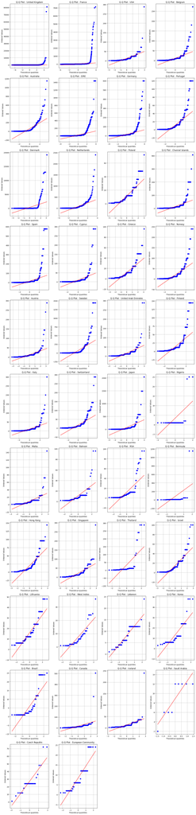

```python
ncols = 4
nrows = (len(countries) + ncols - 1) // ncols

fig, axes = plt.subplots(nrows=nrows, ncols=ncols, figsize=(16, 6 * nrows))

axes = np.array(axes).flatten() if isinstance(axes, np.ndarray) else [axes]

for i, c in enumerate(countries):
    group = df[df['Country'] == c]['Quantity']

    ax = axes[i]
    stats.probplot(group, dist="norm", plot=ax)

    ax.set_title(f"Q-Q Plot - {c}")
    ax.grid(True)

for j in range(i + 1, len(axes)):
    axes[j].axis('off')

plt.tight_layout()
plt.show()
```

#### Teste de Shapiro - Preços

```python
for i, c in enumerate(countries):
    group = df[df['Country'] == c]['Price']
    if len(group) >= 3:
        stat, p_value = stats.shapiro(group)
        message = 'Não é normalmente distribuído' if p_value < 0.05 else 'É normalmente distribuído'
        print(f'Teste para {c}: p-value: {p_value} ===> {message}')
```

```
Teste para United Kingdom: p-value: 1.707408512279894e-237 ===> Não é normalmente distribuído
Teste para France: p-value: 1.2940384927648119e-124 ===> Não é normalmente distribuído
Teste para USA: p-value: 4.0825626576022554e-39 ===> Não é normalmente distribuído
Teste para Belgium: p-value: 3.363891428778634e-82 ===> Não é normalmente distribuído
Teste para Australia: p-value: 2.7560332305438575e-69 ===> Não é normalmente distribuído
Teste para EIRE: p-value: 2.5177859489159775e-130 ===> Não é normalmente distribuído
Teste para Germany: p-value: 1.1845025393573287e-126 ===> Não é normalmente distribuído
Teste para Portugal: p-value: 1.2883603979401294e-77 ===> Não é normalmente distribuído
```

```
Teste para Denmark: p-value: 1.3294321690829774e-37 ===> Não é normalmente distribuído
Teste para Netherlands: p-value: 1.2809339125740976e-91 ===> Não é normalmente distribuído
Teste para Poland: p-value: 1.7930467742709432e-35 ===> Não é normalmente distribuído
Teste para Channel Islands: p-value: 3.6336280936491114e-61 ===> Não é normalmente distribuído
Teste para Spain: p-value: 6.501695253718244e-86 ===> Não é normalmente distribuído
Teste para Cyprus: p-value: 9.605208652254344e-57 ===> Não é normalmente distribuído
Teste para Greece: p-value: 5.544215289531044e-38 ===> Não é normalmente distribuído
Teste para Norway: p-value: 7.062914621835598e-65 ===> Não é normalmente distribuído
Teste para Austria: p-value: 6.535213255286641e-49 ===> Não é normalmente distribuído
Teste para Sweden: p-value: 1.736507662466474e-62 ===> Não é normalmente distribuído
Teste para United Arab Emirates: p-value: 2.4562706334487646e-42 ===> Não é normalmente distribuído
Teste para Finland: p-value: 1.854304714718822e-52 ===> Não é normalmente distribuído
Teste para Italy: p-value: 7.985114802650236e-62 ===> Não é normalmente distribuído
Teste para Switzerland: p-value: 1.1353747518914395e-81 ===> Não é normalmente distribuído
Teste para Japan: p-value: 1.0108298110801014e-26 ===> Não é normalmente distribuído
Teste para Nigeria: p-value: 1.2397511558703773e-08 ===> Não é normalmente distribuído
Teste para Malta: p-value: 7.678206648856267e-35 ===> Não é normalmente distribuído
Teste para Bahrain: p-value: 4.9714610347496237e-11 ===> Não é normalmente distribuído
Teste para RSA: p-value: 5.038998067441901e-28 ===> Não é normalmente distribuído
Teste para Bermuda: p-value: 3.451531051703077e-07 ===> Não é normalmente distribuído
Teste para Hong Kong: p-value: 5.0883769893654e-38 ===> Não é normalmente distribuído
Teste para Singapore: p-value: 5.155206624644028e-37 ===> Não é normalmente distribuído
Teste para Thailand: p-value: 6.286165930957339e-11 ===> Não é normalmente distribuído
Teste para Israel: p-value: 1.527030822457033e-35 ===> Não é normalmente distribuído
Teste para Lithuania: p-value: 1.3653805334835187e-09 ===> Não é normalmente distribuído
Teste para West Indies: p-value: 2.0356840142519128e-07 ===> Não é normalmente distribuído
Teste para Lebanon: p-value: 2.3557104624956943e-10 ===> Não é normalmente distribuído
Teste para Korea: p-value: 0.001480863705130825 ===> Não é normalmente distribuído
Teste para Brazil: p-value: 1.02521324008897e-09 ===> Não é normalmente distribuído
Teste para Canada: p-value: 5.836335033322714e-32 ===> Não é normalmente distribuído
Teste para Iceland: p-value: 5.443064226365984e-19 ===> Não é normalmente distribuído
Teste para Saudi Arabia: p-value: 0.1416746152406994 ===> É normalmente distribuído
Teste para Czech Republic: p-value: 1.019663403718647e-09 ===> Não é normalmente distribuído
Teste para European Community: p-value: 2.6194814847881623e-07 ===> Não é normalmente distribuído
```

#### Teste de Shapiro - Quantidades

```python
for i, c in enumerate(countries):
    group = df[df['Country'] == c]['Quantity']
    if len(group) >= 3:
        stat, p_value = stats.shapiro(group)
        message = 'Não é normalmente distribuído' if p_value < 0.05 else 'É normalmente distribuído'
        print(f'Teste para {c}: p-value: {p_value} ===> {message}')
```

```
Teste para United Kingdom: p-value: 2.8602770732180945e-237 ===> Não é normalmente distribuído
Teste para France: p-value: 1.0871859857578239e-123 ===> Não é normalmente distribuído
Teste para USA: p-value: 1.6863505774477194e-33 ===> Não é normalmente distribuído
Teste para Belgium: p-value: 2.901459946953303e-66 ===> Não é normalmente distribuído
Teste para Australia: p-value: 1.1432487257874258e-52 ===> Não é normalmente distribuído
Teste para EIRE: p-value: 6.933897596015562e-121 ===> Não é normalmente distribuído
Teste para Germany: p-value: 1.0421583450057505e-115 ===> Não é normalmente distribuído
Teste para Portugal: p-value: 6.519152191676133e-56 ===> Não é normalmente distribuído
Teste para Denmark: p-value: 1.3388192251614838e-49 ===> Não é normalmente distribuído
Teste para Netherlands: p-value: 1.632273987035867e-73 ===> Não é normalmente distribuído
Teste para Poland: p-value: 1.8076586917757845e-25 ===> Não é normalmente distribuído
Teste para Channel Islands: p-value: 6.2226838622488065e-58 ===> Não é normalmente distribuído
Teste para Spain: p-value: 1.1520654952096494e-81 ===> Não é normalmente distribuído
Teste para Cyprus: p-value: 5.510940709224385e-54 ===> Não é normalmente distribuído
Teste para Greece: p-value: 3.1527188217277947e-30 ===> Não é normalmente distribuído
Teste para Norway: p-value: 5.28202793788697e-47 ===> Não é normalmente distribuído
Teste para Austria: p-value: 2.486691555011568e-47 ===> Não é normalmente distribuído
Teste para Sweden: p-value: 3.43013579348719e-52 ===> Não é normalmente distribuído
Teste para United Arab Emirates: p-value: 3.75847923461448e-36 ===> Não é normalmente distribuído
Teste para Finland: p-value: 2.8565061052855213e-45 ===> Não é normalmente distribuído
Teste para Italy: p-value: 2.075009368564579e-55 ===> Não é normalmente distribuído
Teste para Switzerland: p-value: 1.6401826649244774e-64 ===> Não é normalmente distribuído
Teste para Japan: p-value: 5.86812581486822e-38 ===> Não é normalmente distribuído
Teste para Nigeria: p-value: 2.489078437326388e-10 ===> Não é normalmente distribuído
Teste para Malta: p-value: 8.362451596221507e-29 ===> Não é normalmente distribuído
Teste para Bahrain: p-value: 9.136737209602556e-19 ===> Não é normalmente distribuído
Teste para RSA: p-value: 7.871668463838758e-21 ===> Não é normalmente distribuído
Teste para Bermuda: p-value: 1.0602288812839188e-11 ===> Não é normalmente distribuído
Teste para Hong Kong: p-value: 1.370457801371509e-24 ===> Não é normalmente distribuído
Teste para Singapore: p-value: 7.894561206187389e-27 ===> Não é normalmente distribuído
Teste para Thailand: p-value: 2.4998092890854223e-15 ===> Não é normalmente distribuído
Teste para Israel: p-value: 5.743418841312845e-22 ===> Não é normalmente distribuído
Teste para Lithuania: p-value: 9.206568375293078e-13 ===> Não é normalmente distribuído
Teste para West Indies: p-value: 5.642567242327184e-08 ===> Não é normalmente distribuído
Teste para Lebanon: p-value: 4.990917670544269e-05 ===> Não é normalmente distribuído
Teste para Korea: p-value: 8.303881956697778e-09 ===> Não é normalmente distribuído
Teste para Brazil: p-value: 7.187225425643555e-13 ===> Não é normalmente distribuído
Teste para Canada: p-value: 4.972214644598399e-30 ===> Não é normalmente distribuído
Teste para Iceland: p-value: 9.532656710174288e-29 ===> Não é normalmente distribuído
Teste para Saudi Arabia: p-value: 0.007285599762249434 ===> Não é normalmente distribuído
Teste para Czech Republic: p-value: 0.0004067493052990638 ===> Não é normalmente distribuído
Teste para European Community: p-value: 3.2780024078046424e-07 ===> Não é normalmente distribuído
```

### Homocedasticidade

```python
stat, p_levene_qty = stats.levene(*[df[df['Country'] == c]['Quantity'] for c in countries])
stat, p_levene_price = stats.levene(*[df[df['Country'] == c]['Price'] for c in countries])

print(f"P-valor do teste de Levene (Quantidade): {p_levene_qty:.4f}")
print(f"P-valor do teste de Levene (Preço): {p_levene_price:.4f}")

if p_levene_qty > 0.05:
    print("As variâncias das quantidades são homogêneas (homocedasticidade confirmada)")
else:
    print("As variâncias das quantidades não são homogêneas (homocedasticidade violada)")

if p_levene_price > 0.05:
    print("As variâncias dos preços são homogêneas (homocedasticidade confirmada)")
else:
    print("As variâncias dos preços não são homogêneas (homocedasticidade violada)")
```

```
P-valor do teste de Levene (Quantidade): 0.0000
P-valor do teste de Levene (Preço): 0.0000
As variâncias das quantidades não são homogêneas (homocedasticidade violada)
As variâncias dos preços não são homogêneas (homocedasticidade violada)
```

### Independência dos erros

#### Resíduos - Preço

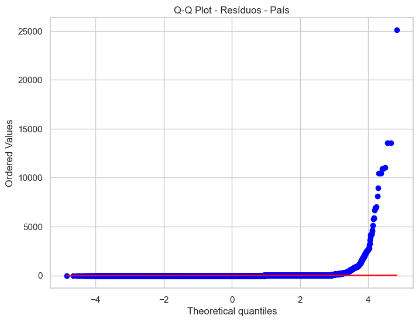

```python
model = smf.ols("Price ~ Q('Country')", data=df).fit()
residuals = model.resid

sns.set_theme(style="whitegrid", palette="Set2")

fig, ax = plt.subplots(figsize=(8, 6))

stats.probplot(residuals, dist="norm", plot=ax)
plt.title('Q-Q Plot - Resíduos - País')
plt.show()
```

#### Resíduos - Quantidades

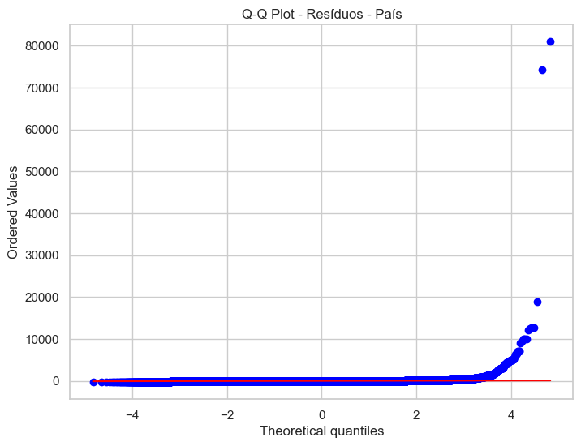

```python
model = smf.ols("Quantity ~ Q('Country')", data=df).fit()
residuals = model.resid

sns.set_theme(style="whitegrid", palette="Set2")

fig, ax = plt.subplots(figsize=(8, 6))

stats.probplot(residuals, dist="norm", plot=ax)
plt.title('Q-Q Plot - Resíduos - País')
plt.show()
```

## Teste não-paramétrico (Kruskal-Wallis)

### Preços

```python
from scipy.stats import kruskal


stat, p = kruskal(*[df[df['Country'] == c]['Price'] for c in countries])
print('Estatítistica= %.3f, p=%.3f' % (stat, p))

alpha = 0.05
if p > alpha:
    print('Os grupos têm a mesma distribuição de preços. (Não rejeita H0)')
else:
    print('Pelo menos um dos grupos possui uma distribuição diferente de preços (rejeita H0)')
```

```
Estatítistica= 2208.445, p=0.000
Pelo menos um dos grupos possui uma distribuição diferente de preços (rejeita H0)
```

### Quantidades

```python
from scipy.stats import kruskal


stat, p = kruskal(*[df[df['Country'] == c]['Quantity'] for c in countries])
print('Estatítistica= %.3f, p=%.3f' % (stat, p))

alpha = 0.05
if p > alpha:
    print('Os grupos têm a mesma distribuição de quantidades de venda. (Não rejeita H0)')
else:
    print('Pelo menos um dos grupos possui uma distribuição diferente de quantidades de venda (rejeita H0)')
```

```
Estatítistica= 52830.554, p=0.000
Pelo menos um dos grupos possui uma distribuição diferente de quantidades de venda (rejeita H0)
```

## Teste pós-hoc (Dunn)

### Preços

```python
dunn_results = sp.posthoc_dunn(df, val_col='Price', group_col='Country', p_adjust='bonferroni')
```

```python
print('Distribuições significativamente diferentes (Preços):')
mask = (dunn_results < 0.05) & (dunn_results != 1)
for i in range(len(dunn_results)):
    for j in range(i):
        if mask.iloc[i, j]:
            print(f'{dunn_results.index[i]} vs {dunn_results.index[j]}, p-valor: {dunn_results.iloc[i, j]:.6f}')
```

```
Distribuições significativamente diferentes (Preços):
Canada vs Bahrain, p-valor: 0.000327
Canada vs Belgium, p-valor: 0.000176
Channel Islands vs Australia, p-valor: 0.000000
Channel Islands vs Austria, p-valor: 0.000000
Channel Islands vs Belgium, p-valor: 0.000002
Channel Islands vs Canada, p-valor: 0.000000
Cyprus vs Australia, p-valor: 0.000000
Cyprus vs Austria, p-valor: 0.000000
Cyprus vs Belgium, p-valor: 0.000000
Cyprus vs Canada, p-valor: 0.000000
Czech Republic vs Cyprus, p-valor: 0.049487
Denmark vs Bahrain, p-valor: 0.004833
Denmark vs Belgium, p-valor: 0.000008
Denmark vs Channel Islands, p-valor: 0.000000
Denmark vs Cyprus, p-valor: 0.000000
EIRE vs Australia, p-valor: 0.000000
EIRE vs Austria, p-valor: 0.001921
EIRE vs Canada, p-valor: 0.000000
EIRE vs Channel Islands, p-valor: 0.012382
EIRE vs Cyprus, p-valor: 0.000000
EIRE vs Denmark, p-valor: 0.000000
European Community vs Canada, p-valor: 0.000079
European Community vs Denmark, p-valor: 0.001168
Finland vs Canada, p-valor: 0.002461
Finland vs Channel Islands, p-valor: 0.000559
Finland vs Cyprus, p-valor: 0.000000
Finland vs Denmark, p-valor: 0.004810
France vs Belgium, p-valor: 0.000000
France vs Channel Islands, p-valor: 0.000000
France vs Cyprus, p-valor: 0.000000
France vs EIRE, p-valor: 0.000000
France vs European Community, p-valor: 0.013990
Germany vs Belgium, p-valor: 0.030548
Germany vs Canada, p-valor: 0.031194
Germany vs Channel Islands, p-valor: 0.000000
Germany vs Cyprus, p-valor: 0.000000
Germany vs Denmark, p-valor: 0.043080
Germany vs EIRE, p-valor: 0.000000
Germany vs France, p-valor: 0.000376
```

[output cut: 183 more lines]

```
United Kingdom vs Japan, p-valor: 0.000000
United Kingdom vs Lebanon, p-valor: 0.007476
United Kingdom vs Netherlands, p-valor: 0.000000
United Kingdom vs Norway, p-valor: 0.000001
United Kingdom vs Portugal, p-valor: 0.000001
United Kingdom vs Spain, p-valor: 0.040049
United Kingdom vs Sweden, p-valor: 0.000000
United Kingdom vs Switzerland, p-valor: 0.000000
United Kingdom vs USA, p-valor: 0.000715
United Kingdom vs United Arab Emirates, p-valor: 0.000000
West Indies vs Channel Islands, p-valor: 0.028939
West Indies vs Cyprus, p-valor: 0.001108
West Indies vs European Community, p-valor: 0.014470
West Indies vs Italy, p-valor: 0.049359
West Indies vs Lebanon, p-valor: 0.000076
```

### Quantidades

```python
dunn_results = sp.posthoc_dunn(df, val_col='Quantity', group_col='Country', p_adjust='bonferroni')
```

```python
print('Distribuições significativamente diferentes (Quantidades):')
mask = (dunn_results < 0.05) & (dunn_results != 1)
for i in range(len(dunn_results)):
    for j in range(i):
        if mask.iloc[i, j]:
            print(f'{dunn_results.index[i]} vs {dunn_results.index[j]}, p-valor: {dunn_results.iloc[i, j]:.6f}')
```

```
Distribuições significativamente diferentes (Quantidades):
Austria vs Australia, p-valor: 0.000000
Bahrain vs Australia, p-valor: 0.000385
Belgium vs Australia, p-valor: 0.000000
Brazil vs Australia, p-valor: 0.000000
Brazil vs Austria, p-valor: 0.000000
Brazil vs Bahrain, p-valor: 0.000125
Brazil vs Belgium, p-valor: 0.000000
Brazil vs Bermuda, p-valor: 0.000040
Canada vs Brazil, p-valor: 0.000000
Channel Islands vs Australia, p-valor: 0.000000
Channel Islands vs Brazil, p-valor: 0.000000
Cyprus vs Australia, p-valor: 0.000000
Cyprus vs Austria, p-valor: 0.000000
Cyprus vs Bahrain, p-valor: 0.048086
Cyprus vs Belgium, p-valor: 0.000000
Cyprus vs Bermuda, p-valor: 0.012300
Cyprus vs Canada, p-valor: 0.000000
Cyprus vs Channel Islands, p-valor: 0.000000
Czech Republic vs Brazil, p-valor: 0.000000
Czech Republic vs Cyprus, p-valor: 0.000084
Denmark vs Austria, p-valor: 0.000000
Denmark vs Bahrain, p-valor: 0.000011
Denmark vs Belgium, p-valor: 0.000000
Denmark vs Brazil, p-valor: 0.000000
Denmark vs Channel Islands, p-valor: 0.000000
Denmark vs Cyprus, p-valor: 0.000000
EIRE vs Australia, p-valor: 0.000000
EIRE vs Brazil, p-valor: 0.000000
EIRE vs Cyprus, p-valor: 0.000000
EIRE vs Denmark, p-valor: 0.000000
European Community vs Australia, p-valor: 0.002417
European Community vs Denmark, p-valor: 0.000179
Finland vs Australia, p-valor: 0.000000
Finland vs Brazil, p-valor: 0.000000
Finland vs Cyprus, p-valor: 0.000000
Finland vs Denmark, p-valor: 0.000000
France vs Australia, p-valor: 0.000000
France vs Brazil, p-valor: 0.000000
France vs Cyprus, p-valor: 0.000000
```

[output cut: 316 more lines]

```
West Indies vs Canada, p-valor: 0.010723
West Indies vs Czech Republic, p-valor: 0.003847
West Indies vs Denmark, p-valor: 0.000000
West Indies vs Germany, p-valor: 0.026442
West Indies vs Hong Kong, p-valor: 0.000351
West Indies vs Iceland, p-valor: 0.009118
West Indies vs Japan, p-valor: 0.000290
West Indies vs Lithuania, p-valor: 0.000005
West Indies vs Netherlands, p-valor: 0.000000
West Indies vs Nigeria, p-valor: 0.000680
West Indies vs Norway, p-valor: 0.000148
West Indies vs Singapore, p-valor: 0.000043
West Indies vs Sweden, p-valor: 0.000000
West Indies vs Switzerland, p-valor: 0.001773
West Indies vs United Arab Emirates, p-valor: 0.007281
```

## Conclusões e tomada de decisão

### Não Validação dos Pressupostos

Isso levou à necessidade de utilizar testes não paramétricos, como o teste de Kruskal-Wallis e o teste de Dunn, que não exigem a normalidade dos dados.

### Testes de Kruskal-Wallis e Dunn

O teste de Kruskal-Wallis foi utilizado para verificar se havia diferenças significativas nas vendas entre os países. Esse teste é uma alternativa não paramétrica à ANOVA e é adequado para comparar três ou mais grupos independentes. O resultado do teste indicou que há diferenças significativas nas vendas entre os países.

Posteriormente, o teste de Dunn foi aplicado para identificar entre quais países essas diferenças eram significativas. Esse teste é uma extensão do teste de Kruskal-Wallis e permite comparar pares de grupos para determinar onde estão as diferenças. Os resultados do teste de Dunn forneceram insights sobre quais países apresentavam diferenças significativas em relação aos outros.

### Possíveis Decisões Estratégicas

Com base nos resultados encontrados, algumas decisões estratégicas podem ser tomadas:

Segmentação de Mercado: Identificar os países com maiores volumes de vendas e concentrar esforços de marketing e vendas nesses mercados. Países com vendas significativamente maiores podem ser alvos prioritários para campanhas promocionais e expansão de estoque.

Ajuste de Preços: Analisar os preços médios por país e ajustar estratégias de precificação para maximizar a receita. Países com preços médios mais altos podem ser explorados para aumentar a margem de lucro, enquanto países com preços mais baixos podem receber descontos ou promoções para aumentar o volume de vendas.

Diversificação de Produtos: Considerar a diversificação de produtos oferecidos em diferentes países, com base nas preferências locais e no comportamento de compra observado. Isso pode ajudar a atender melhor às demandas específicas de cada mercado.

Melhoria da Logística: Países com volumes de vendas significativamente menores podem indicar problemas de logística ou distribuição. Investir em melhorias na cadeia de suprimentos para esses países pode aumentar a eficiência e, consequentemente, as vendas.

Análise de Tendências: Continuar monitorando as tendências de vendas e preços ao longo do tempo para identificar mudanças no comportamento do consumidor e ajustar as estratégias de acordo.